# Tidy Tuesday

Week 36

Author

Cristian T

Published

September 14, 2024

This week we are exploring the Stack Overflow Annual Developer Survey 2024!

This week’s dataset is derived from the 2024 Stack Overflow Annual Developer Survey. Conducted in May 2024, the survey gathered responses from over 65,000 developers across seven key sections:

- Basic information
- Education, work, and career
- Tech and tech culture
- Stack Overflow community
- Artificial Intelligence (AI)
- Professional Developer Series - Not part of the main survey
- Thoughts on Survey

The dataset provided for this analysis focuses exclusively on the single-response questions from the main survey sections. Each categorical response in the survey has been integer-coded, with corresponding labels available in the crosswalk file.

`qname_levels_single_response_crosswalk.csv`

| variable | class | description |
| --- | --- | --- |
| qname | character | Categorical Question/Column Name in main data |
| level | integer | Integer index associated with each column response |
| label | character | Label associated with integer index |

`stackoverflow_survey_questions.csv`

| variable | class | description |
| --- | --- | --- |
| qname | character | Categorical Question/Column Name in main data |
| question | character | Text of the question as it was presented to the respondent |
| variable | class | description |

`stackoverflow_survey_single_response.csv`

| variable | class | description |
| --- | --- | --- |
| response_id | double | Respondent ID |
| main_branch | integer | Professional coding level of the respondent |
| age | integer | Age |
| remote_work | integer | Current work situation |
| ed_level | integer | Highest education level completed |
| years_code | integer | Years the respondent has coded in total; More than 50 years coded as 51 |
| years_code_pro | integer | Years the respondent has coded professionally; More than 50 years coded as 51 |
| dev_type | integer | Best current-job description |
| org_size | integer | People in the organization |
| purchase_influence | integer | Level of influence in purchasing new technology at their organization |
| buildvs_buy | integer | How much customization was needed in most recent tool recommendation |
| country | character | Country in which the respondent lives |
| currency | character | Currency of the country |
| comp_total | double | Total compensation |
| so_visit_freq | integer | Stack Overflow visiting frequency |
| so_account | integer | Stack Overflow account status |
| so_part_freq | integer | Stack Overflow participation frequency |
| so_comm | integer | Whether the respondent considers themself a member of the Stack Overflow community? |
| ai_select | integer | Use AI in development process |
| ai_sent | integer | Stance on using AI tools as part of development workflow |
| ai_acc | integer | Trust in accuracy of AI as part of development workflow |
| ai_complex | integer | How well the respondent believes the AI tools they use in development workflows handle complex tasks |
| ai_threat | integer | Belief that AI is a threat to current job |
| survey_length | integer | Feeling about the length of the Stack Overflow Developer Survey this year |
| survey_ease | integer | Ease of completion of this survey |
| converted_comp_yearly | double | Converted compensation |
| r_used | integer | Flag if respondent used R in the previous year |
| r_want_to_use | integer | Flag if respondent want to use R in the next year |

```r
# Load the tidytuesday package
suppressMessages(library(tidytuesdayR)) # For accessing TidyTuesday datasets
suppressMessages(library(skimr)) # For summary and descriptive statistics
suppressMessages(library(tidyverse)) # For data manipulation and visualization
suppressMessages(library(dplyr)) # For data manipulation and transformation
suppressMessages(library(ggplot2)) # For data visualization
suppressMessages(library(RColorBrewer)) # For color palettes in visualizations
suppressMessages(library(mdsr)) # For spatial analysis
suppressMessages(library(tidytext)) # For text mining and analysis
suppressMessages(library(textstem)) # For lemmatization


# Load the current week's dataset
tuesdata <- tidytuesdayR::tt_load('2024-09-03')
# Extract datasets from the TidyTuesday dataset
qname_levels_single_response_crosswalk <- tuesdata$qname_levels_single_response_crosswalk
stackoverflow_survey_questions <- tuesdata$stackoverflow_survey_questions
stackoverflow_survey_single_response <- tuesdata$stackoverflow_survey_single_response

# Rename datasets
survey_questions <- stackoverflow_survey_questions
survey_responses <- stackoverflow_survey_single_response
qname_levels <- qname_levels_single_response_crosswalk

# Explore the structure of the dataset
str(survey_questions) # Display the structure of 'survey_questions' (type of variables, number of observations)
```

```
spc_tbl_ [24 × 2] (S3: spec_tbl_df/tbl_df/tbl/data.frame)
 $ qname   : chr [1:24] "main_branch" "age" "remote_work" "ed_level" ...
 $ question: chr [1:24] "Which of the following options best describes you today? For the purpose of this survey, a developer is \"someo"| __truncated__ "What is your age?*" "Which best describes your current work situation?" "Which of the following best describes the highest level of formal educati…
 - attr(*, "spec")=
  .. cols(
  ..   qname = col_character(),
  ..   question = col_character()
  .. )
 - attr(*, "problems")=<externalptr>
```

```r
#skim(survey_questions)

# Explore the structure of the survey responses dataset
str(survey_responses) # Display the structure of 'survey_responses'
```

```
spc_tbl_ [65,437 × 28] (S3: spec_tbl_df/tbl_df/tbl/data.frame)
 $ response_id          : num [1:65437] 1 2 3 4 5 6 7 8 9 10 ...
 $ main_branch          : num [1:65437] 1 1 1 2 1 4 3 2 4 1 ...
 $ age                  : num [1:65437] 8 3 4 1 1 8 3 1 4 3 ...
 $ remote_work          : num [1:65437] 3 3 3 NA NA NA 3 NA 2 3 ...
 $ ed_level             : num [1:65437] 4 2 3 7 6 4 5 6 5 3 ...
 $ years_code           : num [1:65437] NA 20 37 4 9 10 7 1 20 15 ...
 $ years_code_pro       : num [1:65437] NA 17 27 NA NA NA 7 NA NA 11 ...
 $ dev_type             : num [1:65437] NA 16 10 16 16 33 1 33 1 16 ...
 $ org_size             : num [1:65437] NA NA NA NA NA NA NA NA NA NA ...
 $ purchase_influence   : num [1:65437] NA NA NA NA NA NA NA NA NA NA ...
 $ buildvs_buy          : num [1:65437] NA NA NA NA NA NA NA NA NA NA ...
 $ country              : chr [1:65437] "United States of America" "United Kingdom of Great Britain and Northern Ireland" "United Kingdom of Great Britain and Northern Ireland" "Canada" ...
 $ currency             : chr [1:65437] NA NA NA NA ...
 $ comp_total           : num [1:65437] NA NA NA NA NA NA NA NA NA NA ...
 $ so_visit_freq        : num [1:65437] NA 5 5 3 5 5 3 4 5 2 ...
 $ so_account           : num [1:65437] NA 3 3 1 3 3 3 1 3 3 ...
 $ so_part_freq         : num [1:65437] NA 6 6 NA 6 6 3 NA 6 5 ...
 $ so_comm              : num [1:65437] NA 5 5 3 5 5 5 2 5 6 ...
 $ ai_select            : num [1:65437] 3 1 1 3 1 3 1 3 1 3 ...
 $ ai_sent              : num [1:65437] 5 NA NA 5 NA 1 NA 2 NA 2 ...
 $ ai_acc               : num [1:65437] NA NA NA 5 NA 5 NA 4 NA 3 ...
 $ ai_complex           : num [1:65437] NA NA NA 1 NA 2 NA 1 NA 1 ...
 $ ai_threat            : num [1:65437] NA NA NA 2 NA 2 NA 3 NA 1 ...
 $ survey_length        : num [1:65437] NA NA 1 2 3 1 2 1 1 2 ...
 $ survey_ease          : num [1:65437] NA NA 2 2 2 2 3 1 3 2 ...
 $ converted_comp_yearly: num [1:65437] NA NA NA NA NA NA NA NA NA NA ...
 $ r_used               : num [1:65437] NA 0 0 0 0 0 1 0 0 0 ...
 $ r_want_to_use        : num [1:65437] NA 0 0 0 0 0 1 0 0 0 ...
 - attr(*, "spec")=
  .. cols(
  ..   response_id = col_double(),
  ..   main_branch = col_double(),
  ..   age = col_double(),
  ..   remote_work = col_double(),
  ..   ed_level = col_double(),
  ..   years_code = col_double(),
  ..   years_code_pro = col_double(),
  ..   dev_type = col_double(),
  ..   org_size = col_double(),
  ..   purchase_influence = col_double(),
  ..   buildvs_buy = col_double(),
  ..   country = col_character(),
  ..   currency = col_character(),
  ..   comp_total = col_double(),
  ..   so_visit_freq = col_double(),
  ..   so_account = col_double(),
  ..   so_part_freq = col_double(),
  ..   so_comm = col_double(),
  ..   ai_select = col_double(),
  ..   ai_sent = col_double(),
  ..   ai_acc = col_double(),
  ..   ai_complex = col_double(),
  ..   ai_threat = col_double(),
  ..   survey_length = col_double(),
  ..   survey_ease = col_double(),
  ..   converted_comp_yearly = col_double(),
  ..   r_used = col_double(),
  ..   r_want_to_use = col_double()
  .. )
 - attr(*, "problems")=<externalptr>
```

```r
skim(survey_responses) # Provide detailed summary statistics for 'survey_responses' (missing values, summary stats)
```

**Variable type: numeric**

| var | n | na | mean | sd | p0 | p25 | p50 | p75 | p100 |
| --- | --- | --- | --- | --- | --- | --- | --- | --- | --- |
| response_id | 65437 | 0 | 3.271900e+04 | 1.889018e+04 | 1 | 16360 | 32719 | 49078.0 | 6.54370e+04 |
| main_branch | 65437 | 0 | 1.500000e+00 | 1.020000e+00 | 1 | 1 | 1 | 1.0 | 5.00000e+00 |
| age | 65437 | 0 | 2.630000e+00 | 1.580000e+00 | 1 | 2 | 2 | 3.0 | 8.00000e+00 |
| remote_work | 65437 | 10631 | 1.960000e+00 | 8.900000e-01 | 1 | 1 | 2 | 3.0 | 3.00000e+00 |
| ed_level | 65437 | 4653 | 3.510000e+00 | 1.930000e+00 | 1 | 2 | 3 | 5.0 | 8.00000e+00 |
| years_code | 65437 | 5568 | 1.420000e+01 | 1.066000e+01 | 0 | 6 | 11 | 20.0 | 5.10000e+01 |
| years_code_pro | 65437 | 13827 | 1.018000e+01 | 9.110000e+00 | 0 | 3 | 7 | 15.0 | 5.10000e+01 |
| dev_type | 65437 | 5992 | 1.717000e+01 | 7.750000e+00 | 1 | 12 | 16 | 19.0 | 3.40000e+01 |
| org_size | 65437 | 17957 | 4.770000e+00 | 2.480000e+00 | 1 | 3 | 5 | 6.0 | 1.00000e+01 |
| purchase_influence | 65437 | 18031 | 2.190000e+00 | 7.700000e-01 | 1 | 2 | 2 | 3.0 | 3.00000e+00 |
| buildvs_buy | 65437 | 22079 | 1.600000e+00 | 8.000000e-01 | 1 | 1 | 1 | 2.0 | 3.00000e+00 |
| comp_total | 65437 | 31697 | 2.963841e+145 | 5.444117e+147 | 0 | 60000 | 110000 | 250000.0 | 1.00000e+150 |
| so_visit_freq | 65437 | 5901 | 2.510000e+00 | 1.270000e+00 | 1 | 2 | 2 | 3.0 | 5.00000e+00 |
| so_account | 65437 | 5877 | 2.600000e+00 | 7.500000e-01 | 1 | 3 | 3 | 3.0 | 3.00000e+00 |
| so_part_freq | 65437 | 20200 | 4.020000e+00 | 1.430000e+00 | 1 | 4 | 5 | 5.0 | 6.00000e+00 |
| so_comm | 65437 | 6274 | 3.360000e+00 | 1.840000e+00 | 1 | 2 | 3 | 5.0 | 6.00000e+00 |
| ai_select | 65437 | 4530 | 2.370000e+00 | 8.500000e-01 | 1 | 2 | 3 | 3.0 | 3.00000e+00 |
| ai_sent | 65437 | 19564 | 2.390000e+00 | 1.680000e+00 | 1 | 1 | 2 | 4.0 | 6.00000e+00 |
| ai_acc | 65437 | 28135 | 3.850000e+00 | 1.210000e+00 | 1 | 3 | 4 | 5.0 | 5.00000e+00 |
| ai_complex | 65437 | 28416 | 2.230000e+00 | 1.110000e+00 | 1 | 1 | 2 | 3.0 | 5.00000e+00 |
| ai_threat | 65437 | 20748 | 1.920000e+00 | 5.600000e-01 | 1 | 2 | 2 | 2.0 | 3.00000e+00 |
| survey_length | 65437 | 9255 | 1.330000e+00 | 5.000000e-01 | 1 | 1 | 1 | 2.0 | 3.00000e+00 |
| survey_ease | 65437 | 9199 | 2.410000e+00 | 5.500000e-01 | 1 | 2 | 2 | 3.0 | 3.00000e+00 |
| converted_comp_yearly | 65437 | 42002 | 8.615529e+04 | 1.867570e+05 | 1 | 32712 | 65000 | 107971.5 | 1.62566e+07 |
| r_used | 65437 | 5692 | 4.000000e-02 | 2.000000e-01 | 0 | 0 | 0 | 0.0 | 1.00000e+00 |
| r_want_to_use | 65437 | 9685 | 4.000000e-02 | 1.900000e-01 | 0 | 0 | 0 | 0.0 | 1.00000e+00 |

```r
# View the first few rows of the dataset
head(survey_questions)
```

| qname | question |
| --- | --- |
| main_branch | Which of the following options best describes you today? For the purpose of this survey, a developer is "someone who writes code".* |
| age | What is your age?* |
| remote_work | Which best describes your current work situation? |
| ed_level | Which of the following best describes the highest level of formal education that you’ve completed? * |
| years_code | Including any education, how many years have you been coding in total? |
| years_code_pro | NOT including education, how many years have you coded professionally (as a part of your work)? |

```r
head(survey_responses)
```

| response_id | main_branch | age | remote_work | ed_level | years_code | years_code_pro | dev_type | org_size | purchase_influence | buildvs_buy | country | currency | comp_total | so_visit_freq | so_account | so_part_freq | so_comm | ai_select | ai_sent | ai_acc | ai_complex | ai_threat | survey_length | survey_ease | converted_comp_yearly | r_used | r_want_to_use |
| --- | --- | --- | --- | --- | --- | --- | --- | --- | --- | --- | --- | --- | --- | --- | --- | --- | --- | --- | --- | --- | --- | --- | --- | --- | --- | --- | --- |
| 1 | 1 | 8 | 3 | 4 | NA | NA | NA | NA | NA | NA | United States of America | NA | NA | NA | NA | NA | NA | 3 | 5 | NA | NA | NA | NA | NA | NA | NA | NA |
| 2 | 1 | 3 | 3 | 2 | 20 | 17 | 16 | NA | NA | NA | United Kingdom of Great Britain and Northern Ireland | NA | NA | 5 | 3 | 6 | 5 | 1 | NA | NA | NA | NA | NA | NA | NA | 0 | 0 |
| 3 | 1 | 4 | 3 | 3 | 37 | 27 | 10 | NA | NA | NA | United Kingdom of Great Britain and Northern Ireland | NA | NA | 5 | 3 | 6 | 5 | 1 | NA | NA | NA | NA | 1 | 2 | NA | 0 | 0 |
| 4 | 2 | 1 | NA | 7 | 4 | NA | 16 | NA | NA | NA | Canada | NA | NA | 3 | 1 | NA | 3 | 3 | 5 | 5 | 1 | 2 | 2 | 2 | NA | 0 | 0 |
| 5 | 1 | 1 | NA | 6 | 9 | NA | 16 | NA | NA | NA | Norway | NA | NA | 5 | 3 | 6 | 5 | 1 | NA | NA | NA | NA | 3 | 2 | NA | 0 | 0 |
| 6 | 4 | 8 | NA | 4 | 10 | NA | 33 | NA | NA | NA | United States of America | NA | NA | 5 | 3 | 6 | 5 | 3 | 1 | 5 | 2 | 2 | 1 | 2 | NA | 0 | 0 |

```r
# Export data
#write.csv(qname_levels_single_response_crosswalk, "qname_levels_single_response_crosswalk.csv", row.names = FALSE)
#write.csv(stackoverflow_survey_questions, "stackoverflow_survey_questions.csv", row.names = FALSE)
#write.csv(stackoverflow_survey_single_response, "stackoverflow_survey_single_response.csv", row.names = FALSE)


#tidytuesdayR::use_tidytemplate()
```

#### Clean the data

```r
# Skim showed a lot of missing values so we will remove rows with missing info
#survey_responses_clean <- survey_responses %>% drop_na()
```

##### Merge the data

We will merge the `qname_levels` and `survey_questions` data frames to get a full picture of the questions.

```r
# Merge qname_levels and survey_questions on the 'qname' column
merged_questions <- merge(qname_levels, survey_questions, by="qname", all=TRUE) %>%
  select(level, question, qname, label, everything())

# Inspect the merged data
head(merged_questions)
```

|  | level | question | qname | label |
| --- | --- | --- | --- | --- |
| 1 | 1 | What is your age?* | age | 18-24 years old |
| 2 | 2 | What is your age?* | age | 25-34 years old |
| 3 | 3 | What is your age?* | age | 35-44 years old |
| 4 | 4 | What is your age?* | age | 45-54 years old |
| 5 | 5 | What is your age?* | age | 55-64 years old |
| 6 | 6 | What is your age?* | age | 65 years or older |

```r
# Remove HTML tags from the 'question' column using regular expressions
merged_questions$question <- gsub("<[^>]+>", "", merged_questions$question)

# Add missing level and label for rows 34-36
merged_questions[34, "level"] <- 1
merged_questions[34, "label"] <- "income"
merged_questions[35, "level"] <- 2
merged_questions[35, "label"] <- "residence"
merged_questions[36, "level"] <- 3
merged_questions[36, "label"] <- "day to day currency"

# Add missing level and label for rows 126 and 127
merged_questions[126, "level"] <- 1
merged_questions[126, "label"] <- "total experience"
merged_questions[127, "level"] <- 2
merged_questions[127, "label"] <- "professional experience"

# Inspect the modified data
head(merged_questions[c(34:36, 126:127), ])
```

|  | level | question | qname | label |
| --- | --- | --- | --- | --- |
| 34 | 1 | What is your current total annual compensation (salary, bonuses, and perks, before taxes and deductions)? Please enter a whole number in the box below, without any punctuation. If you are paid hourly,… | comp_total | income |
| 35 | 2 | Where do you live? * | country | residence |
| 36 | 3 | Which currency do you use day-to-day? If your answer is complicated, please pick the one you're most comfortable estimating in. * | currency | day to day currency |
| 126 | 1 | Including any education, how many years have you been coding in total? | years_code | total experience |
| 127 | 2 | NOT including education, how many years have you coded professionally (as a part of your work)? | years_code_pro | professional experience |

#### EDA

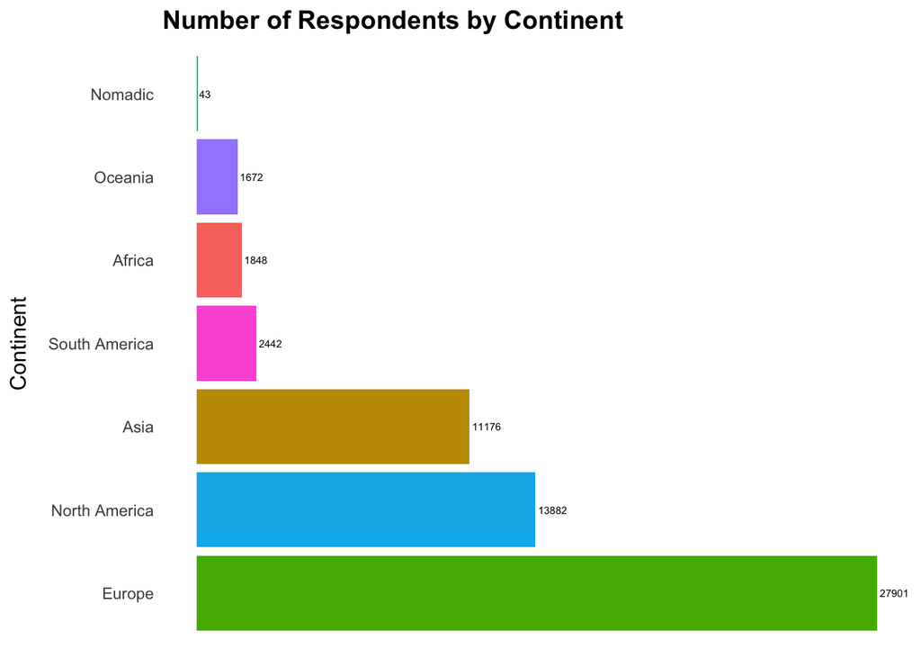

```r
# Load a CSV file that maps countries to continents
manual_continent_mapping <- read.csv("/Users/cristianthirteen/Downloads/Notre Dame/SP 24 Linear Models SP 24/Linear Models Data Sets/Countries-Continents.csv")

# Rename the "Country" column in the manual_continent_mapping to "country" for consistency with survey_responses
manual_continent_mapping <- manual_continent_mapping %>%
  rename(country = Country)

# Merge manual_continent_mapping with survey_responses by the "country" column
survey_responses <- merge(manual_continent_mapping, survey_responses, by = "country", all=TRUE) # The 'all=TRUE' ensures all countries from both datasets are included, even if there's no match


# Create a named vector for the country corrections
country_corrections <- c(
  "Brunei Darussalam" = "Brunei",
  "Burkina Faso" = "Burkina",
  "Congo, Democratic Republic of" = "Congo",
  "Congo, Republic of the..." = "Congo",
  "Democratic Republic of the Congo" = "Congo",
  "Democratic People's Republic of Korea" = "North Korea",
  "Iran, Islamic Republic of..." = "Iran",
  "Lao People's Democratic Republic" = "Laos",
  "Libyan Arab Jamahiriya" = "Libya",
  "Micronesia, Federated States of..." = "Micronesia",
  "Myanmar" = "Burma (Myanmar)",
  "Nomadic" = "Nomadic",
  "Republic of Korea" = "South Korea",
  "Republic of Moldova" = "Moldova",
  "Republic of North Macedonia" = "North Macedonia",
  "Syrian Arab Republic" = "Syria",
  "United Kingdom of Great Britain and Northern Ireland" = "United Kingdom",
  "United Republic of Tanzania" = "Tanzania",
  "Venezuela, Bolivarian Republic of..." = "Venezuela",
  "Viet Nam" = "Vietnam"
)

# Apply the country corrections to the survey_responses dataset
survey_responses<- survey_responses %>%
  mutate(country = recode(country, !!!country_corrections))

# Apply corrections for missing continent names based on the country values
survey_responses <- survey_responses %>%
     mutate(Continent = case_when(
       is.na(Continent) & country == "Brunei" ~ "Asia",
       is.na(Continent) & country == "Burkina" ~ "Africa",
       is.na(Continent) & country == "Congo" ~ "Africa",
       is.na(Continent) & country == "North Korea" ~ "Asia",
       is.na(Continent) & country == "Iran" ~ "Asia",
       is.na(Continent) & country == "Laos" ~ "Asia",
       is.na(Continent) & country == "Libya" ~ "Africa",
       is.na(Continent) & country == "Micronesia" ~ "Oceania",
       is.na(Continent) & country == "Burma (Myanmar)" ~ "Asia",
       is.na(Continent) & country == "Nomadic" ~ "Nomadic",
       is.na(Continent) & country == "South Korea" ~ "Asia",
       is.na(Continent) & country == "Moldova" ~ "Europe",
       is.na(Continent) & country == "North Macedonia" ~ "Europe",
       is.na(Continent) & country == "Syria" ~ "Asia",
       is.na(Continent) & country == "United Kingdom" ~ "Europe",
       is.na(Continent) & country == "Tanzania" ~ "Africa",
       is.na(Continent) & country == "Venezuela" ~ "South America",
       is.na(Continent) & country == "Vietnam" ~ "Asia",
       TRUE ~ Continent
     ))

# Group survey_responses by Continent and count the number of respondents per continent
continent_counts <- survey_responses %>%
  filter(!is.na(Continent)) %>%
  group_by(Continent) %>%
  summarise(count = n()) %>%
  arrange(desc(count)) %>%
  mutate(percentage = (count / sum(count)) * 100)

# Filter rows where country is "Congo"
# survey_responses %>% filter(country == "Congo")


# Plot number of respondents by country
ggplot(continent_counts, aes(x = reorder(Continent, -count), y = count, fill = Continent)) +
  geom_bar(stat = "identity", show.legend = FALSE) +
  geom_text(aes(label = count), hjust = -0.1, size = 2) +
  labs(title = "Number of Respondents by Continent",
       x = "Continent",
       y = "Count") +
  theme_minimal() +
  theme(axis.text.x = element_blank(),
        axis.title.x = element_blank(),
        axis.title.y = element_text(size = 12, margin = margin(r = 10)),
        plot.title = element_text(size = 14, face = "bold"),
        panel.grid.major = element_blank(),
        panel.grid.minor = element_blank()) +
  coord_flip()
```

```r
#write.csv(survey_responses, "survey_responses.csv", row.names = FALSE)
```

The survey data reveals that nearly half (47.3%) of the respondents are from Europe, making it the largest represented continent. North America follows with 23.5% of respondents, and Asia accounts for 19.0%. South America, Africa, and Oceania have smaller representations, with 4.14%, 3.13%, and 2.84% of respondents, respectively. A small fraction (0.073%) of respondents identified as “Nomadic,” reflecting a respondent population that does not associate with a specific continent.

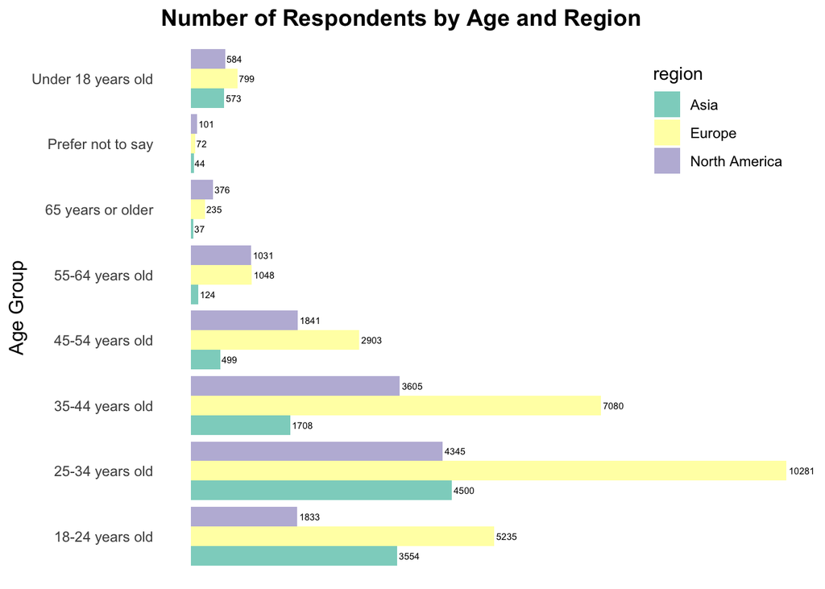

```r
# Rename age groups
age_groups <- survey_responses %>%
  mutate(age = factor(age, levels = 1:8, labels = c(
    "18-24 years old",
    "25-34 years old",
    "35-44 years old",
    "45-54 years old",
    "55-64 years old",
    "65 years or older",
    "Prefer not to say",
    "Under 18 years old"
  )))

# Filter and count by continent and age
continent_age_counts <- age_groups %>%
  filter(!is.na(dev_type)) %>% # Exclude rows with missing 'dev_type'
  filter(Continent %in% c("North America", "Europe", "Asia")) %>%  # Select only the top 3 continents
  mutate(region = case_when(
    Continent == "North America" ~ "North America",
    Continent == "Europe" ~ "Europe",
    Continent == "Asia" ~ "Asia"
  )) %>%
  group_by(region, age) %>% # Group by region and age
  summarise(count = n(), .groups = 'drop') %>% # Count the number of responses in each group
  mutate(percentage = (count / sum(count)) * 100)

# Create a bar plot showing the number of respondents by age and region
ggplot(continent_age_counts, aes(x = age, y = count, fill = region)) +
  geom_bar(stat = "identity", position = "dodge") +
  geom_text(aes(label = count), position = position_dodge(width = 0.9),hjust = -0.1,size = 2) +
  scale_fill_manual(values = brewer.pal(10, "Set3")) +
  labs(title = "Number of Respondents by Age and Region",
       x = "Age Group",
       y = "Count") +
  theme_minimal() +
  theme(axis.text.x = element_blank(),
        axis.title.x = element_blank(),
           axis.title.y = element_text(size = 12),
           plot.title = element_text(size = 14, face = "bold"),
           panel.grid.major = element_blank(),
           panel.grid.minor = element_blank(),
           legend.position = c(0.85, 0.85)) +
     coord_flip()
```

In contrast, older age groups (55 years or older) show generally lower representation across all regions, which might indicate lower engagement or participation rates from older individuals. The percentage of respondents choosing “Prefer not to say” about their age is relatively small across all regions, suggesting that most respondents are comfortable disclosing their age.

#### Plot 2 Counts by Age Group (USA)

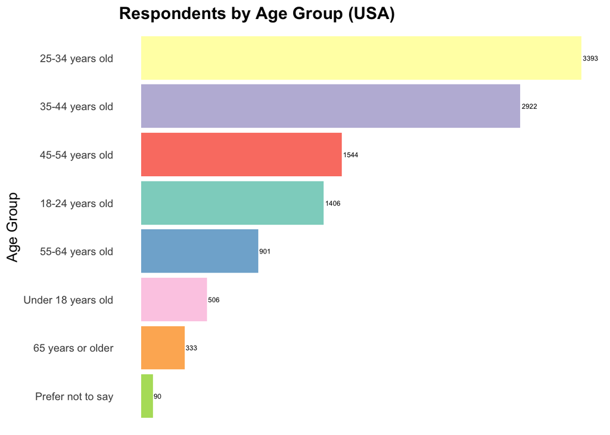

```r
# Filter for USA and aggregate counts by age
usa_age_counts <- age_groups %>%
  filter(country == "United States of America") %>%
  group_by(age) %>%
  summarise(count = n(), .groups = 'drop') %>%
  mutate(percentage = (count / sum(count)) * 100)

# Create a bar plot
ggplot(usa_age_counts, aes(x = reorder(age, count), y = count, fill = age)) +
     geom_bar(stat = "identity") +
     scale_fill_manual(values = brewer.pal(10, "Set3")) +
  geom_text(aes(label = count), hjust = -0.1, size = 2) +
     labs(title = "Respondents by Age Group (USA)",
          x = "Age Group",
          y = "Count",
          fill = "Age Group") +
     theme_minimal() +
     theme(axis.text.x = element_blank(),
        axis.title.x = element_blank(),
           axis.title.y = element_text(size = 12),
           plot.title = element_text(size = 14, face = "bold"),
           panel.grid.major = element_blank(),
           panel.grid.minor = element_blank(),
           legend.position = "none") +  # Remove the legend
     coord_flip()
```

In the US, the age distribution of respondents reveals a significant concentration in the 25-34 age group, constituting 30.6% of the total respondents. The 35-44 age group follows closely, making up 26.3%. 18-24-year-olds account for 12.7%, showing notable but lesser participation than older groups. 45-54 years olds represent 13.9%, maintaining a substantial middle-aged presence. 55-64 years olds make up 8.12%, and those under 18 constitute 4.56%. The 65 and older group is the smallest at 3.00%. Additionally, 0.811% of respondents chose not to disclose their age.

Overall, 56.9% of respondents fall within the 25-44 age range, indicating that the survey predominantly reflects individuals in their prime working years.

#### Plot 3 Counts by Education Level (USA)

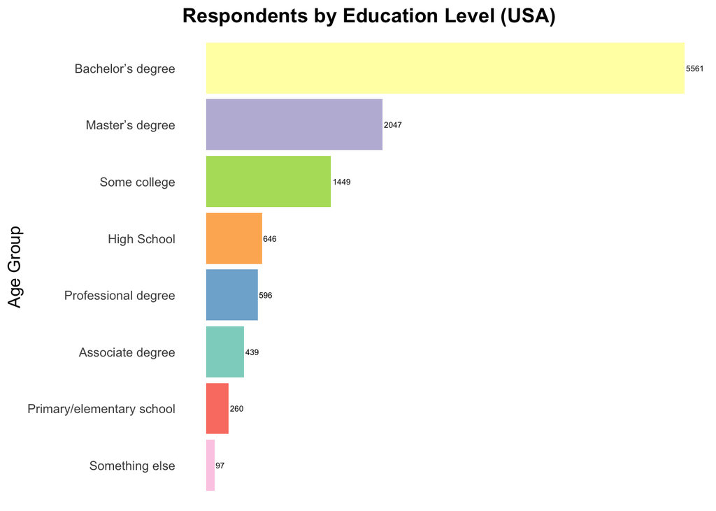

```r
# Rename education
education_level <- survey_responses %>%
  mutate(ed_level = factor(ed_level, levels = 1:8, labels = c(
    "Associate degree",
    "Bachelor’s degree",
    "Master’s degree",
    "Primary/elementary school",
    "Professional degree",
    "High School",
    "Some college",
    "Something else"
  )))


# Filter for USA and aggregate counts by education
usa_edu_counts <- education_level %>%
  filter(country == "United States of America") %>%
  group_by(ed_level) %>%
  summarise(count = n(), .groups = 'drop') %>%
  mutate(percentage = (count / sum(count)) * 100)

# Create a bar plot
ggplot(usa_edu_counts, aes(x = reorder(ed_level, count), y = count, fill = ed_level)) +
     geom_bar(stat = "identity") +
     scale_fill_manual(values = brewer.pal(10, "Set3")) +
  geom_text(aes(label = count), hjust = -0.1, size = 2) +
     labs(title = "Respondents by Education Level (USA)",
          x = "Age Group",
          y = "Count",
          fill = "Age Group") +
     theme_minimal() +
     theme(axis.text.x = element_blank(),
        axis.title.x = element_blank(),
           axis.title.y = element_text(size = 12),
           plot.title = element_text(size = 14, face = "bold"),
           panel.grid.major = element_blank(),
           panel.grid.minor = element_blank(),
           legend.position = "none") +  # Remove the legend
     coord_flip()
```

Our data for the US shows a predominance of Bachelor’s Degree Holders, with 50.1% holding a Bachelor’s degree. We also see a significant amount of graduate degrees, with Master’s degree holders making up 18.4% of the respondents, suggesting that the survey sample is highly educated. We also see people with associate degrees (3.96%), professional degrees (5.37%), high school diplomas (5.82%), and some college degrees (13.1%). The distribution shows a clear preference towards higher education among respondents.

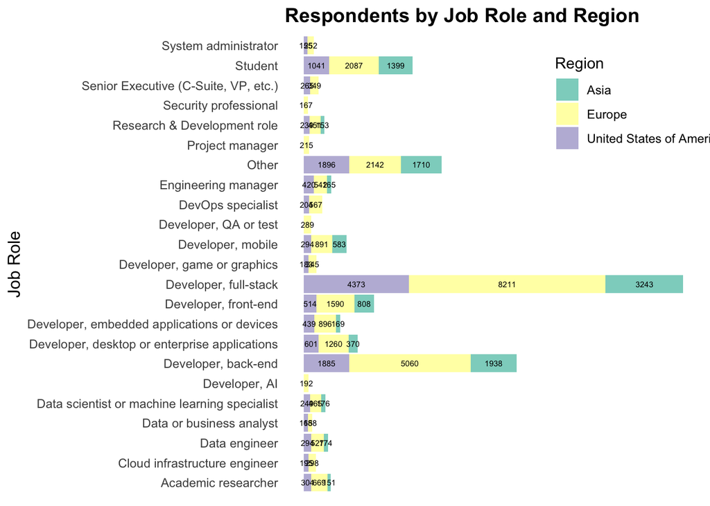

```r
# Rename job roles
dev_roles <- survey_responses %>%
  mutate(dev_type = factor(dev_type, levels = 1:34, labels = c(
    "Academic researcher",
    "Blockchain",
    "Cloud infrastructure engineer",
    "Data engineer",
    "Data or business analyst",
    "Data scientist or machine learning specialist",
    "Database administrator",
    "Designer",
    "Developer Advocate",
    "Developer Experience",
    "Developer, AI",
    "Developer, back-end",
    "Developer, desktop or enterprise applications",
    "Developer, embedded applications or devices",
    "Developer, front-end",
    "Developer, full-stack",
    "Developer, game or graphics",
    "Developer, mobile",
    "Developer, QA or test",
    "DevOps specialist",
    "Educator",
    "Engineer, site reliability",
    "Engineering manager",
    "Hardware Engineer",
    "Marketing or sales professional",
    "Other",
    "Product manager",
    "Project manager",
    "Research & Development role",
    "Scientist",
    "Security professional",
    "Senior Executive (C-Suite, VP, etc.)",
    "Student",
    "System administrator"
  )))

# Filter for top 2 continents, including United States and count respondents by job role
continent_age_counts_dev <- dev_roles %>%
  filter(Continent %in% c("North America", "Europe", "Asia")) %>%
  mutate(region = case_when(
    Continent == "North America" ~ "United States of America",
    Continent == "Europe" ~ "Europe",
    Continent == "Asia" ~ "Asia"
  )) %>%
  group_by(region, dev_type) %>%
  summarise(count = n(), .groups = 'drop') %>%
  mutate(percentage = (count / sum(count)) * 100)

# Group less common job roles into "Other"
threshold <- 150  # Threshold for grouping
grouped_data <- continent_age_counts_dev %>%
  filter(!is.na(dev_type)) %>%
  mutate(dev_type = if_else(count < threshold, "Other", as.character(dev_type))) %>%
  group_by(region, dev_type) %>%
  summarise(count = sum(count), .groups = 'drop') %>%
  mutate(percentage = (count / sum(count)) * 100)


# Create the plot
ggplot(grouped_data, aes(x = dev_type, y = count, fill = region)) +
  geom_bar(stat = "identity", position = "stack") +  # Change to "stack" for stacked bars
  geom_text(aes(label = count), position = position_stack(vjust = 0.5), size = 2) +  # Adjust text position for stacking
  scale_fill_manual(values = brewer.pal(10, "Set3")) +
  labs(title = "Respondents by Job Role and Region",
       x = "Job Role",
       y = "Count",
       fill = "Region") +
  theme_minimal() +
  theme(axis.text.x = element_blank(),
        axis.title.x = element_blank(),
        axis.title.y = element_text(size = 12),
        plot.title = element_text(size = 14, face = "bold"),
        panel.grid.major = element_blank(),
        panel.grid.minor = element_blank(),
        legend.position = c(0.85, 0.85)) +
  coord_flip()  # Flip coordinates for better label readability
```